# SNP Association - Asthma

This analysis aims to identify SNPs that are associated with individuals that have asthma.

```r
library(SNPassoc)
```

Load the data, originally from https://github.com/isglobal-brge/brgedata/blob/master/data/asthma.rda

```r
load("~/Downloads/asthma.rda")
head(asthma)
```

|  | country | gender | age | bmi | smoke | casecontrol | rs4490198 | rs4849332 | rs1367179 | rs11123242 | rs13014858 | rs1430094 | rs1430093 | rs746710 | rs1430090 | rs6737251 | rs11685217 | rs1430097 | rs10496465 | rs3756688 | rs2303063 | rs1422993 | rs2400478 | rs714588 | rs1023555 | rs898070 | rs963218 | rs1419835 | rs765023 | … |
| --- | --- | --- | --- | --- | --- | --- | --- | --- | --- | --- | --- | --- | --- | --- | --- | --- | --- | --- | --- | --- | --- | --- | --- | --- | --- | --- | --- | --- | --- | --- |
| 1 | Germany | Males | 42.80630 | 20.14797 | 1 | 0 | GG | TT | GC | CT | AA | AA | AA | CC | TG | CC | CC | CC | AG | TT | AA | GG | GG | AG | AA | GA | CC | CT | TT | … |
| 2 | Germany | Males | 50.22861 | 24.69136 | 0 | 0 | GG | GT | GC | CT | GA | GA | CA | CC | GG | CC | CC | CC | AG | TC | AG | GT | GA | AA | TT | GG | CC | CC | TT | … |
| 3 | Germany | Males | 46.68857 | 27.73230 | 0 | 0 | GG | TT | GC | CT | AA | AA | AA | CC | TT | TT | CT | AA | AA | TC | AG | GG | GG | AG | TA | GG | CT | CT | CC | … |
| 4 | Germany | Females | 47.86311 | 33.33187 | 0 | 0 | AG | GT | GG | CC | GA | GA | CA | GC | TT | CT | CT | CA | AA | CC | GG | GT | GA | AG | TT | GA | CT | CC | TC | … |
| 5 | Germany | Females | 48.44079 | 25.23634 | 0 | 1 | AG | GG | GG | CC | GG | GG | CC | GC | TT | TT | CT | AA | AA | TC | AG | GT | GA | AA | TT | GG | CC | CC | TC | … |
| 6 | Germany | Females | 36.90075 | 29.37240 | 1 | 0 | AG | GT | GG | CC | GA | GA | CA | GC | TT | CC | CC | CA | AA | TC | AG | GG | GG | AG | TA | GG | CT | CT | CC | … |

Take a closer look at the features.

```r
 str(asthma, list.len=9)
```

```
'data.frame':   1578 obs. of  57 variables:
 $ country    : Factor w/ 10 levels "Australia","Belgium",..: 5 5 5 5 5 5 5 5 5 5 ...
 $ gender     : Factor w/ 2 levels "Females","Males": 2 2 2 1 1 1 1 2 1 1 ...
 $ age        : num  42.8 50.2 46.7 47.9 48.4 ...
 $ bmi        : num  20.1 24.7 27.7 33.3 25.2 ...
 $ smoke      : int  1 0 0 0 0 1 0 0 0 0 ...
 $ casecontrol: int  0 0 0 0 1 0 0 0 0 0 ...
 $ rs4490198  : Factor w/ 3 levels "AA","AG","GG": 3 3 3 2 2 2 3 2 2 2 ...
 $ rs4849332  : Factor w/ 3 levels "GG","GT","TT": 3 2 3 2 1 2 3 3 2 1 ...
 $ rs1367179  : Factor w/ 3 levels "CC","GC","GG": 2 2 2 3 3 3 2 3 3 3 ...
  [list output truncated]
```

Identify which columns contain the SNP data.

```r
 asthma.s <- setupSNP(data=asthma, colSNPs=7:ncol(asthma), sep="")
```

Let’s take a look at one of those columns.

```r
 head(asthma.s$rs1422993)
```

```
[1] G/G G/T G/G G/T G/T G/G
Genotypes: G/G G/T T/T
Alleles:  G T
```

```r
 class(asthma.s$rs1422993)
```

```
[1] "snp"    "factor"
```

Summarise the content of this SNP.

```r
summary(asthma.s$rs1422993)
```

```
Genotypes:
    frequency percentage
G/G       903  57.224335
G/T       570  36.121673
T/T       105   6.653992

Alleles:
  frequency percentage
G      2376   75.28517
T       780   24.71483

HWE (p value): 0.250093
```

```r
 head(summary(asthma.s))
```

```
           alleles major.allele.freq HWE      missing (%)
rs4490198  A/G     59.2              0.174133  0.6
rs4849332  G/T     61.8              0.522060  0.1
rs1367179  G/C     81.4              0.738153  1.0
rs11123242 C/T     81.7              0.932898  0.6
rs13014858 G/A     58.3              0.351116  0.1
rs1430094  G/A     66.9              0.305509  0.4
rs1430093  C/A     66.6              0.817701  3.5
rs746710   G/C     51.5              0.614368  0.0
rs1430090  T/G     70.0              0.025180  1.6
rs6737251  C/T     69.3              0.235996  0.3
rs11685217 C/T     80.1              0.009462  4.5
rs1430097  C/A     65.1              0.738166  1.0
rs10496465 A/G     85.8              0.917997  0.6
rs3756688  T/C     63.9              0.154632  0.6
rs2303063  A/G     53.0              0.722069  1.1
rs1422993  G/T     75.3              0.250093  0.0
rs2400478  G/A     62.6              0.256786  0.9
rs714588   A/G     54.9              0.838329  0.8
rs1023555  T/A     76.8              0.943443  0.5
rs898070   G/A     62.6              1.000000  0.6
rs963218   C/T     53.2              0.389387  0.3
rs1419835  C/T     78.2              0.505391  0.6
rs765023   T/C     64.5              0.030513  6.9
rs1345267  A/G     61.0              0.112183  0.1
rs324381   G/A     64.6              0.242223 11.6
hopo546333 G/A     93.3              0.309476  0.7
rs184448   T/G     55.9              0.008446  2.2
rs324396   C/T     71.2              0.197291  0.3
rs324957   G/A     57.0              0.007417  0.4
rs324960   C/T     66.6              0.077777  1.1
rs10486657 C/T     81.3              0.672703  4.3
rs324981   A/T     53.2              0.048438  0.2
rs1419780  C/G     80.8              0.569652  0.2
rs325462   T/A     51.0              0.337862  0.3
rs727162   G/C     78.5              0.765708  0.0
rs10250709 G/A     65.4              0.266434  0.0
rs6958905  T/C     64.7              0.377472  0.4
rs10238983 T/C     75.7              0.216435  0.4
rs4941643  A/G     54.1              0.635887  7.2
rs3794381  C/G     71.7              0.652089  7.1
rs2031532  G/A     65.0              0.911918  0.0
rs2247119  T/C     71.5              0.457710  0.5
rs8000149  T/C     63.2              0.588077  0.4
rs2274276  G/C     57.0              0.571386  0.6
rs7332573  G/T     91.5              0.869947  1.5
rs3829366  T/A     51.6              0.722626  1.3
rs6084432  G/A     83.7              0.266716  0.6
rs512625   G/A     69.5              0.905395  0.4
rs3918395  G/T     86.8              0.508732  1.2
rs2787095  G/C     60.2              0.102053  0.8
rs2853215  G/A     73.0              0.249516  0.2
```

|  | alleles | major.allele.freq | HWE | missing |
| --- | --- | --- | --- | --- |
| rs4490198 | A/G | 59.2 | 0.174133 | 0.6 |
| rs4849332 | G/T | 61.8 | 0.522060 | 0.1 |
| rs1367179 | G/C | 81.4 | 0.738153 | 1.0 |
| rs11123242 | C/T | 81.7 | 0.932898 | 0.6 |
| rs13014858 | G/A | 58.3 | 0.351116 | 0.1 |
| rs1430094 | G/A | 66.9 | 0.305509 | 0.4 |

See where the missing values and if there are any patterns here.

```
'drop' argument will be ignored
```

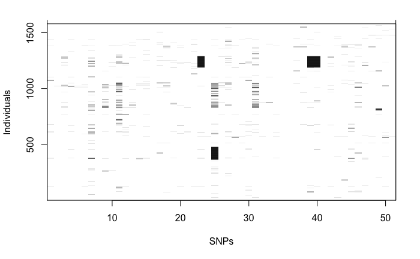

```r
 plotMissing(asthma.s, print.labels.SNPs = FALSE)
```

See which SNPs do not meet the Hardy-Weinberg equilibrium.

```r
hwe <- tableHWE(asthma.s, casecontrol)

threshold <- 0.05 / 51
snpNHWE <- hwe2[,2] < threshold
rownames(hwe)[snpNHWE]
```

```
character(0)
```

```r
hwe[snpNHWE,]
```

```
     all groups 0 1
```

All SNPs meet the HWE in the control group, so none of them need to be removed from the dataset before further analysis.

For a bit of fun, let’s find the SNP that is most outside the HWE.

```r
which.min(hwe[,3])
```

```
rs184448
      27
```

Perform an association analysis between rs184448 and the casecontrol.

```r
association(casecontrol ~ rs184448, data = asthma.s)
```

```
SNP: rs184448  adjusted by:
                0    %   1    %   OR lower upper  p-value  AIC
Codominant
T/T           381 31.5  76 22.8 1.00             0.006777 1606
T/G           624 51.5 189 56.8 1.52  1.13  2.04
G/G           206 17.0  68 20.4 1.65  1.14  2.39
Dominant
T/T           381 31.5  76 22.8 1.00             0.001832 1604
T/G-G/G       830 68.5 257 77.2 1.55  1.17  2.06
Recessive
T/T-T/G      1005 83.0 265 79.6 1.00             0.154665 1612
G/G           206 17.0  68 20.4 1.25  0.92  1.70
Overdominant
T/T-G/G       587 48.5 144 43.2 1.00             0.090054 1611
T/G           624 51.5 189 56.8 1.23  0.97  1.58
log-Additive
0,1,2        1211 78.4 333 21.6 1.30  1.09  1.55 0.004112 1606
```

The dominant model is the most statistically significant, as individuals with this SNP seem to be 55% more likely to have asthma if they have this mutation.

```r
maxstat(asthma.s$casecontrol, asthma.s$rs184448)
```

```
     dominant recessive log-additive MAX-statistic  Pr(>z)
[1,]    9.710     2.026        8.253         9.710 0.00332 **
---
Signif. codes:  0 ‘***’ 0.001 ‘**’ 0.01 ‘*’ 0.05 ‘.’ 0.1 ‘ ’ 1
```

Control for a few variables to see how that affects the significance.

```r
association(casecontrol ~ rs184448 + gender + smoke + bmi, asthma.s)
```

[output not shown]

```
SNP: rs184448  adjusted by: gender smoke bmi
                0    %   1    %   OR lower upper   p-value  AIC
Codominant
T/T           379 31.5  72 22.4 1.00             0.0033366 1542
T/G           620 51.5 183 57.0 1.56  1.15  2.12
G/G           205 17.0  66 20.6 1.77  1.21  2.59
Dominant
T/T           379 31.5  72 22.4 1.00             0.0009985 1541
T/G-G/G       825 68.5 249 77.6 1.61  1.20  2.16
Recessive
T/T-T/G       999 83.0 255 79.4 1.00             0.0907466 1549
G/G           205 17.0  66 20.6 1.32  0.96  1.80
Overdominant
T/T-G/G       584 48.5 138 43.0 1.00             0.0999837 1549
T/G           620 51.5 183 57.0 1.23  0.96  1.59
log-Additive
0,1,2        1204 79.0 321 21.0 1.34  1.12  1.61 0.0016801 1542
```

The p-value has decreased and is now close to our threshold.

To further inspect the data, we can take a look at the association when smoking is modeled as a factor.

```r
association(casecontrol ~ dominant(rs184448)*factor(smoke), data=asthma.s)
```

```
      SNP: dominant(rs184448  adjusted by:
 Interaction
---------------------
          0       OR lower upper   1      OR lower upper
T/T     251  58 1.00    NA    NA 128 18 0.61  0.34  1.08
T/G-G/G 570 194 1.47  1.06  2.05 256 62 1.05  0.70  1.56

p interaction: 0.63789

 factor(smoke) within dominant(rs184448
---------------------
T/T
```

|  | 0 | 1 | OR | lower | upper |
| --- | --- | --- | --- | --- | --- |
| 0 | 251 | 58 | 1.00 | NA | NA |
| 1 | 128 | 18 | 0.61 | 0.34 | 1.08 |

```
T/G-G/G
```

|  | 0 | 1 | OR | lower | upper |
| --- | --- | --- | --- | --- | --- |
| 0 | 570 | 194 | 1.00 | NA | NA |
| 1 | 256 | 62 | 0.71 | 0.52 | 0.98 |

```
p trend: 0.63789

 dominant(rs184448 within factor(smoke)
---------------------
0
```

|  | 0 | 1 | OR | lower | upper |
| --- | --- | --- | --- | --- | --- |
| T/T | 251 | 58 | 1.00 | NA | NA |
| T/G-G/G | 570 | 194 | 1.47 | 1.06 | 2.05 |

[output not shown]

|  | 0 | 1 | OR | lower | upper |
| --- | --- | --- | --- | --- | --- |
| T/T | 128 | 18 | 1.00 | NA | NA |
| T/G-G/G | 256 | 62 | 1.72 | 0.98 | 3.03 |

```
p trend: 0.63789
```

Expand the analysis to perform a whole genome association analysis using all of the SNPs.

```r
ans <- WGassociation(casecontrol, data=asthma.s)
head(ans)
```

```
           comments codominant dominant recessive overdominant log-additive
rs4490198         -    0.52765  0.29503   0.96400      0.29998      0.49506
rs4849332         -    0.96912  0.92986   0.84806      0.82327      0.97049
rs1367179         -    0.62775  0.59205   0.35786      0.86419      0.43994
rs11123242        -    0.68622  0.67596   0.39801      0.92878      0.52009
rs13014858        -    0.52578  0.26739   0.88011      0.34966      0.40897
rs1430094         -    0.13375  0.10569   0.54432      0.04490      0.36611
```

Plot the results.

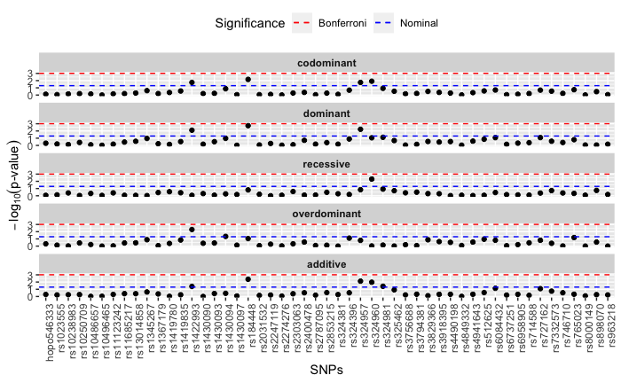

```r
plot(ans)
```

None of the SNPs meet our significance threshold.

```r
ans.max[,ans.max["Pr(>z)",] <= threshold]
```

[output not shown]

Try to find significance once more after controlling for a few variables.

```r
ans2 <- WGassociation(casecontrol ~ gender + smoke + bmi, data=asthma.s)
```

[output not shown]

[figure not shown]

```r
plot(ans)
```

Still nothing as none of the p-value cross the significance threshold with the Bonferroni adjustment.